# MOFA drug effect

```r
library(tidyverse)
library(MOFA2)
library(here)
#library(MOFAdata)
library(ReactomePA)
library(biomaRt)
library(gridExtra)
library(cowplot)
```

## Introduction

I start out by loading the trained MOFA model and additional gene expression data.

```r
# input data
morphology_profile <- readRDS(here::here("data/processed/morphology/pca_absolute_all_drugs_aggregate.Rds"))

# input model
model <- load_model(here("models/mofa/model.hdf5"))

# model outputs
weights <- model@expectations$Z$single_group %>% as.data.frame() %>% rownames_to_column("id") %>% as_tibble() %>% janitor::clean_names()
loadings_size <- model@expectations$W$size_view %>% as.data.frame() %>% rownames_to_column("id") %>% as_tibble() %>% janitor::clean_names()
loadings_expression <- model@expectations$W$expression %>% as.data.frame() %>% rownames_to_column("id") %>% as_tibble() %>% janitor::clean_names()
loadings_morphology <- model@expectations$W$morphology %>% as.data.frame() %>% rownames_to_column("id") %>% as_tibble() %>% janitor::clean_names()
loadings_drug_activity <- model@expectations$W$drug_activity %>% as.data.frame() %>% rownames_to_column("id") %>% as_tibble() %>% janitor::clean_names()
loadings_mutation <- model@expectations$W$mutation %>% as.data.frame() %>% rownames_to_column("id") %>% as_tibble() %>% janitor::clean_names()

# additional data
## UMAP morphology
umap_df <- readRDS(here::here("data/processed/morphology/umap_absolute_all_drugs_sampled.Rds"))
## gene expression baseline
promise_long_filtered_top <- readRDS(here::here('data/processed/expression/promise_expr_filtered_tidy_top.rds'))
## gene expression drug response
# expr_long_gsk <- readRDS(here::here("data/processed/expression/gsk_expr_tidy.rds"))
# expr_long_mek <- readRDS(here::here("data/processed/expression/mek_expr_tidy.rds"))
```

Next, I use the organoid phenotype profiles to estimate factor scores given the models trained loadings. I do not supply additional data.

# morphology -> factor

```r
new_morphology <- morphology_profile %>%
  filter(concentration == "nan") %>%
  mutate(rep = paste0("r", replicate)) %>%
  mutate(line = substr(line, 1, 4)) %>%
  mutate(line = paste0(line, "_", rep, "_", drug)) %>%
  dplyr::select(line, contains("pc")) %>%
  # I treat every drug induced phenotype as a dedicated line
  # accounting for D020T duplicate
  group_by(line) %>%
  summarise_at(vars(contains("pc")), funs(mean)) %>%
  ungroup() %>% column_to_rownames("line") %>% as.matrix() %>%
  scale(scale = FALSE, center = FALSE)

new_morphology_conc <- morphology_profile %>%
  #filter(concentration != "nan") %>%
  mutate(rep = paste0("r", replicate)) %>%
  mutate(line = substr(line, 1, 4)) %>%
  mutate(line = paste0(line, "_", rep, "_", drug, "_", concentration)) %>%
  dplyr::select(line, contains("pc")) %>%
  # I treat every drug induced phenotype as a dedicated line
  # accounting for D020T duplicate
  group_by(line) %>%
  summarise_at(vars(contains("pc")), funs(mean)) %>%
  ungroup() %>% column_to_rownames("line") %>% as.matrix() %>%
  scale(scale = FALSE, center = FALSE)

# extracting model loadings for morphology view
W <- get_weights(model, "morphology_view")[[1]]
Winv <- pracma::pinv(W)

z_projected <-  new_morphology %*% t(Winv) %>% as.data.frame()%>% rownames_to_column("id")
z_projected_concentration <-  new_morphology_conc %*% t(Winv) %>% as.data.frame()%>% rownames_to_column("id")
```

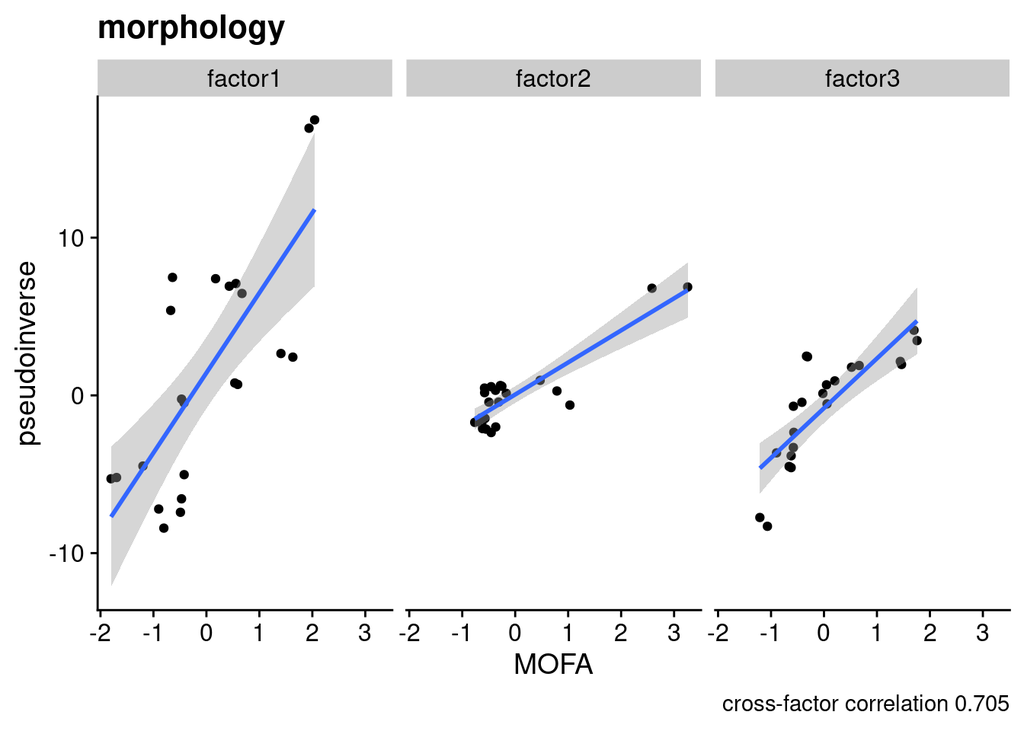

```r
z_projected_anno <- z_projected %>%
  mutate(target = substr(id, 9, nchar(id))) %>%
  mutate(line = substr(id, 1, 7)) %>%
  dplyr::rename(drug_id = id,
                id = line)

z_projected_anno_plot_df <- z_projected_anno %>%
  filter(target == "DMSO") %>%
  left_join(weights) %>%
  dplyr::select(-target, -drug_id) %>%
  gather(variable, value, -id) %>%
  mutate(factor = if_else(variable %in% c("V1", "factor1"), "factor1", "none")) %>%
  mutate(factor = if_else(variable %in% c("V2", "factor2"), "factor2", factor)) %>%
  mutate(factor = if_else(variable %in% c("V3", "factor3"), "factor3", factor)) %>%
  mutate(source = if_else(grepl(variable, pattern = "factor"), "MOFA", "pseudoinverse")) %>%
  dplyr::select(-variable)

df <- z_projected_anno_plot_df %>%
  spread(source, value)

r <- cor(df$MOFA, df$pseudoinverse) %>% round(3)

z_projected_anno_plot_df %>%
  spread(source, value) %>%
  ggplot(aes(MOFA, pseudoinverse)) +
  geom_point() +
  facet_wrap(~ factor) +
  theme_cowplot() +
  geom_smooth(method = "lm") +
  labs(title = "morphology",
       caption = paste0("cross-factor correlation ", r))
```

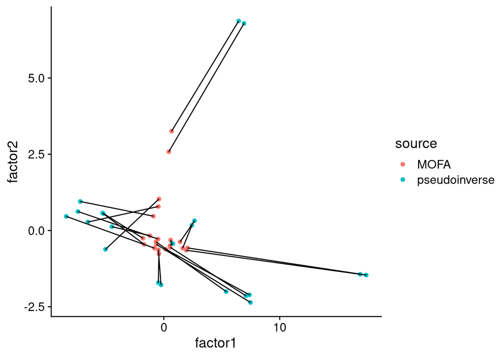

```r
z_projected_anno_plot_df %>%
  spread(factor, value) %>%
  ggplot(aes(factor1, factor2, color = source)) +
  geom_point() +
  geom_path(aes(group = id), color = "black") +
  theme_cowplot() +
 # ggrepel::geom_text_repel(aes(label = id), data = z_projected_expression_plot %>%
 # spread(factor, value) %>% filter(source == "MOFA"), color = "black")
  NULL
```

# morhphology: MOA

```r
## load drug annotation
drug_anno <- readxl::read_excel(here::here('references/layouts/Compound_Annotation_Libraries_New.xlsx')) %>% distinct(drug = `Compound name`, target = `Primary Target`)

z_projected_anno_tidy <- z_projected_anno %>%
  dplyr::rename(drug = target) %>%
  left_join(drug_anno) %>%
  mutate(line = substr(id, 1, 4))

z_projected_anno_test <- z_projected_anno_tidy %>% semi_join(z_projected_anno_tidy %>%
                                                               dplyr::select(target, drug) %>%
                                                               distinct() %>%
                                            dplyr::count(target) %>%
                                            filter(n >=5)) %>%
  filter(drug != "DMSO")
```

```r
drug_projection_test_result <- rbind(
  lm(V1 ~ target, data = z_projected_anno_test) %>% summary() %>% broom::tidy() %>% mutate(factor = "factor1"),
  lm(V2 ~ target, data = z_projected_anno_test) %>% summary() %>% broom::tidy() %>% mutate(factor = "factor2"),
  lm(V3 ~ target, data = z_projected_anno_test) %>% summary() %>% broom::tidy() %>% mutate(factor = "factor3"))

drug_projection_test_result <- drug_projection_test_result %>%
  filter(term != "(Intercept)") %>%
  dplyr::select(term, statistic, factor, p.value)
```

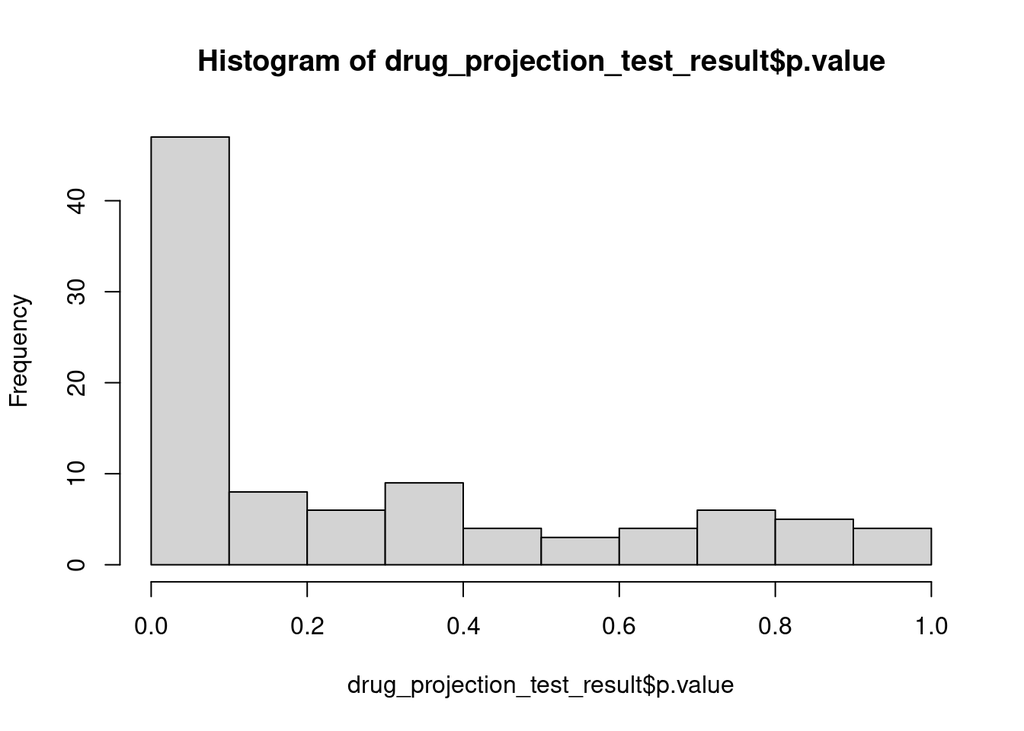

```r
hist(drug_projection_test_result$p.value)
```

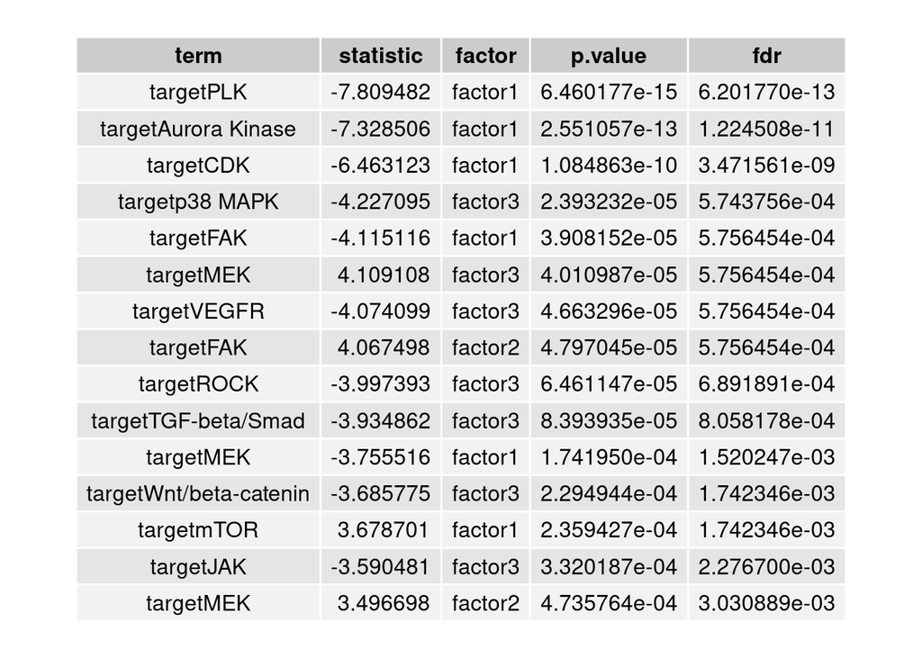

```r
moa_factor_shift <- drug_projection_test_result %>% arrange(p.value) %>%
  mutate(fdr = p.adjust(p.value, method = "BH"))


moa_factor_shift_tbl <- moa_factor_shift%>%
  filter(fdr <= 0.2) %>%
  head(15) %>%
  tableGrob(., theme = ttheme_default(), rows = NULL)

grid.arrange(moa_factor_shift_tbl)
```

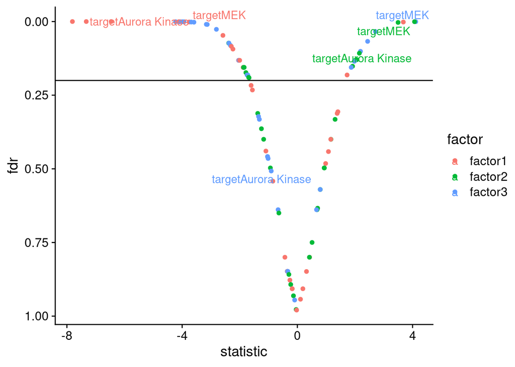

```r
moa_factor_shift %>%
  ggplot(aes(statistic, fdr, color = factor, label = term)) +
  geom_point() +
  scale_y_reverse() +
  geom_hline(yintercept = 0.2) +
  theme_cowplot() +
  #facet_wrap( ~ factor)+
  ggrepel::geom_text_repel(data = moa_factor_shift %>% filter(term == "targetMEK")) +
  ggrepel::geom_text_repel(data = moa_factor_shift %>% filter(term == "targetAurora Kinase"))
```

```r
  NULL
```

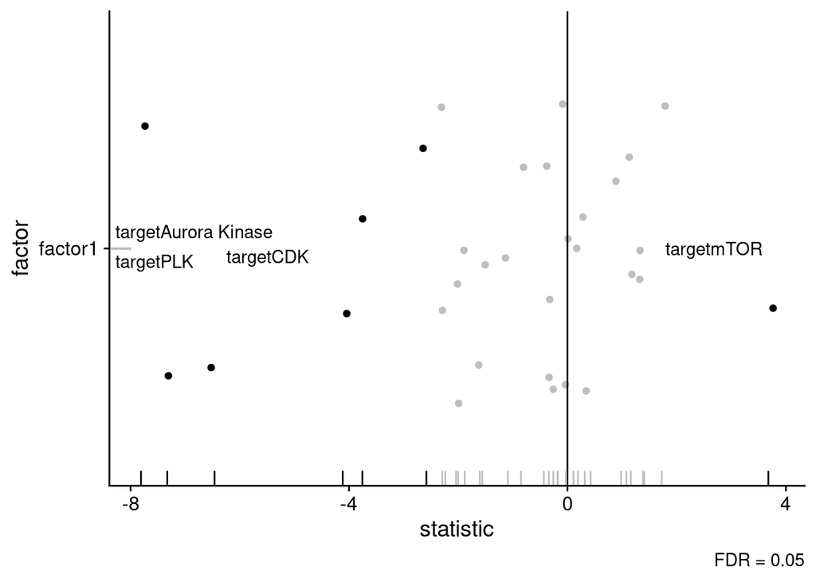

```r
set.seed(12234533)
df <- moa_factor_shift %>%
  filter(factor == "factor1") %>%
  mutate(fdr_bool = if_else(fdr < 0.05, TRUE, FALSE)) %>%
  filter((term == "targetmTOR") | (term %in% c("targetAurora Kinase", "targetCDK", "targetPLK")) & factor ==  "factor1")

# gg_shift <- moa_factor_shift %>%
#   filter(factor == "factor1") %>%
#   ggplot(aes(statistic)) +
#   geom_vline(xintercept = 0) +
#   geom_histogram(aes(fill = factor), alpha = 0.2) +
#   geom_rug(aes(color = factor)) +
#
#   geom_vline(data = df, aes(xintercept = statistic, color = factor), linetype="dashed") +
#   geom_text(aes(x= df %>% filter(factor == "factor1") %>% .$statistic - .5,
#                 label= df %>% filter(factor == "factor1") %>% .$term, y=.350), color = "black") +
#   geom_text(aes(x= df %>% filter(factor == "factor1") %>% .$statistic %>% .[1] + .5,
#                 label= df %>% filter(factor == "factor1") %>% .$term %>% .[1], y=.350), color = "black") +
#   geom_text(aes(x= df %>% filter(factor == "factor1") %>% .$statistic %>% .[2] + .5,
#               label= df %>% filter(factor == "factor1") %>% .$term %>% .[2], y=.370), color = "black") +
#   theme_cowplot() +
#   theme(legend.position = "bottom")
#
# gg_shift + ggsave(here::here("reports/figures/mofa/drug_shift.pdf"), width = 3, height = 3)


gg_shift <- moa_factor_shift %>%
  mutate(fdr_bool = if_else(fdr < 0.05, TRUE, FALSE)) %>%
  filter(factor == "factor1") %>%
  ggplot(aes(statistic, factor, label = term, color = fdr_bool)) +
  geom_jitter(width = 0.1) +
  geom_vline(xintercept = 0) +
   ggrepel::geom_text_repel(data = df) +
  theme_cowplot() +
  scale_color_manual(values = c("grey", "black")) +
  geom_rug() +
  theme(legend.position =  "nothing") +
  labs(caption = "FDR = 0.05")

gg_shift + ggsave(here::here("reports/figures/mofa/f1_moa_shift.pdf"), width = 6, height = 2)
```

```r
moa_factor_shift %>%
  mutate(fdr_bool = if_else(fdr < 0.05, TRUE, FALSE)) %>%
  filter(factor == "factor1") %>%
  write_csv(here::here("reports/tables/source_data_f1_moa_shift_6f.csv"))
```

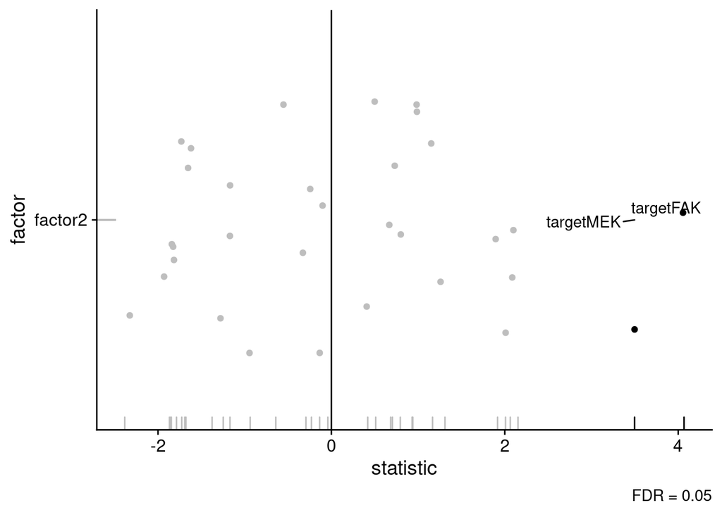

```r
set.seed(123)

df <- moa_factor_shift %>%
  filter(factor == "factor2") %>%
  mutate(fdr_bool = if_else(fdr < 0.05, TRUE, FALSE)) %>%
  filter((term %in% c("targetMEK", "targetFAK")))

# gg_shift <- moa_factor_shift %>%
#   filter(factor != "factor3") %>%
#   ggplot(aes(statistic)) +
#   geom_vline(xintercept = 0) +
#   geom_density(aes(fill = factor), alpha = 0.2) +
#   geom_rug(aes(color = factor)) +
#
#   geom_vline(data = df, aes(xintercept = statistic, color = factor), linetype="dashed") +
#   geom_text(aes(x= df %>% filter(factor == "factor2") %>% .$statistic - .5,
#                 label= df %>% filter(factor == "factor2") %>% .$term, y=.350), color = "black") +
#   geom_text(aes(x= df %>% filter(factor == "factor1") %>% .$statistic %>% .[1] + .5,
#                 label= df %>% filter(factor == "factor1") %>% .$term %>% .[1], y=.350), color = "black") +
#   geom_text(aes(x= df %>% filter(factor == "factor1") %>% .$statistic %>% .[2] + .5,
#               label= df %>% filter(factor == "factor1") %>% .$term %>% .[2], y=.370), color = "black") +
#   theme_cowplot() +
#   theme(legend.position = "bottom")

gg_shift <- moa_factor_shift %>%
  mutate(fdr_bool = if_else(fdr < 0.05, TRUE, FALSE)) %>%
  filter(factor == "factor2") %>%
  ggplot(aes(statistic, factor, label = term, color = fdr_bool)) +
  geom_jitter(width = 0.1) +
  geom_vline(xintercept = 0) +
   ggrepel::geom_text_repel(data = df) +
  theme_cowplot() +
  scale_color_manual(values = c("grey", "black")) +
  geom_rug() +
  theme(legend.position =  "nothing") +
  labs(caption = "FDR = 0.05")

gg_shift + ggsave(here::here("reports/figures/mofa/f2_moa_shift.pdf"), width = 6, height = 2)
```

```r
moa_factor_shift %>%
  mutate(fdr_bool = if_else(fdr < 0.05, TRUE, FALSE)) %>%
  filter(factor == "factor2") %>%
  write_csv(here::here("reports/tables/source_data_f2_moa_shift_5f.csv"))
```

aurora kinase, PLK, CDK, leads to reduced factor 1 - smaller organoids mTORi leads to increased factor 1 - larger organoids? MEK, FAK leads to increased factor 2 - more cystic organoids

Wnt inhibitors lead to reduced factor 3 -

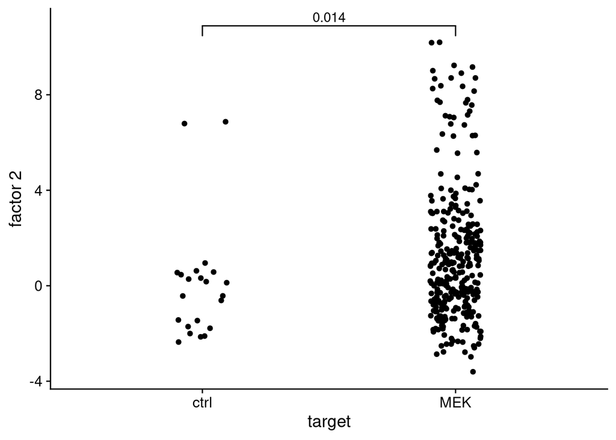

```r
doi <- c("MEK", "ctrl")

z_projected_anno_tidy %>%
  mutate(target = if_else(drug == "DMSO", "ctrl", target)) %>%
  left_join(drug_projection_test_result %>% dplyr::rename(target = term)) %>%
  #filter(line %in% c("D004_r1", "D004_r2", "D007_r1", "D007_r2", "D019_r1", "D019_r2")) %>%
  filter(target %in% doi) %>%
  ggplot(aes(target, V2, label = id)) +
  geom_jitter(width = 0.1) +
  ggsignif::geom_signif(comparisons = list(doi)) +
  theme_cowplot() +
  labs(y = "factor 2")
```

## concentration dependend effects

I check wether these shifts in factor scores are a function of drug concentration

```r
z_projected_conc_anno <- z_projected_concentration %>%
  mutate(target = substr(id, 9, nchar(id))) %>%
  separate(target, c("target", "concentration"), sep = "_") %>%
  mutate(concentration = as.numeric(concentration)) %>%
  mutate(line = substr(id, 1, 7)) %>%
  mutate(target = ifelse(target == "", "DMSO", target))

z_projected_conc_anno_tidy <- z_projected_conc_anno %>%
  dplyr::rename(drug = target) %>%
  left_join(drug_anno)
```

### MEK inhibitors

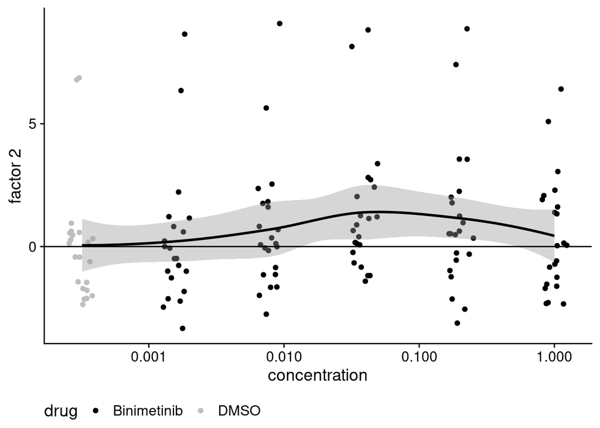

```r
gg_f2_mek_conc <- z_projected_conc_anno_tidy %>%
  filter(drug %in% c("DMSO", "Binimetinib")) %>%
  mutate(concentration = if_else(drug == "DMSO", 0.00032, concentration)) %>% #adding a pseudo conc for plotting
  ggplot(aes(concentration, V2)) +
  geom_jitter(width = 0.1, aes(color = drug)) +
  scale_x_log10() +
  geom_smooth(color = "black") +
  geom_hline(yintercept = 0) +
  theme_cowplot() +
  labs(y = "factor 2") +
  scale_color_manual(values = c("black", "grey")) +
  theme(legend.position = "bottom")

gg_f2_mek_conc + ggsave(here::here("reports/figures/mofa/f2_mek_shift.pdf"), width = 4, height = 4)
```

```r
z_projected_conc_anno_tidy %>%
  filter(drug %in% c("DMSO", "Binimetinib")) %>%
  mutate(concentration = if_else(drug == "DMSO", 0.00032, concentration)) %>%
  dplyr::select(concentration, V2) %>%
  write_csv(here::here("reports/tables/source_data_f2_mek_shift_5g.csv"))
```

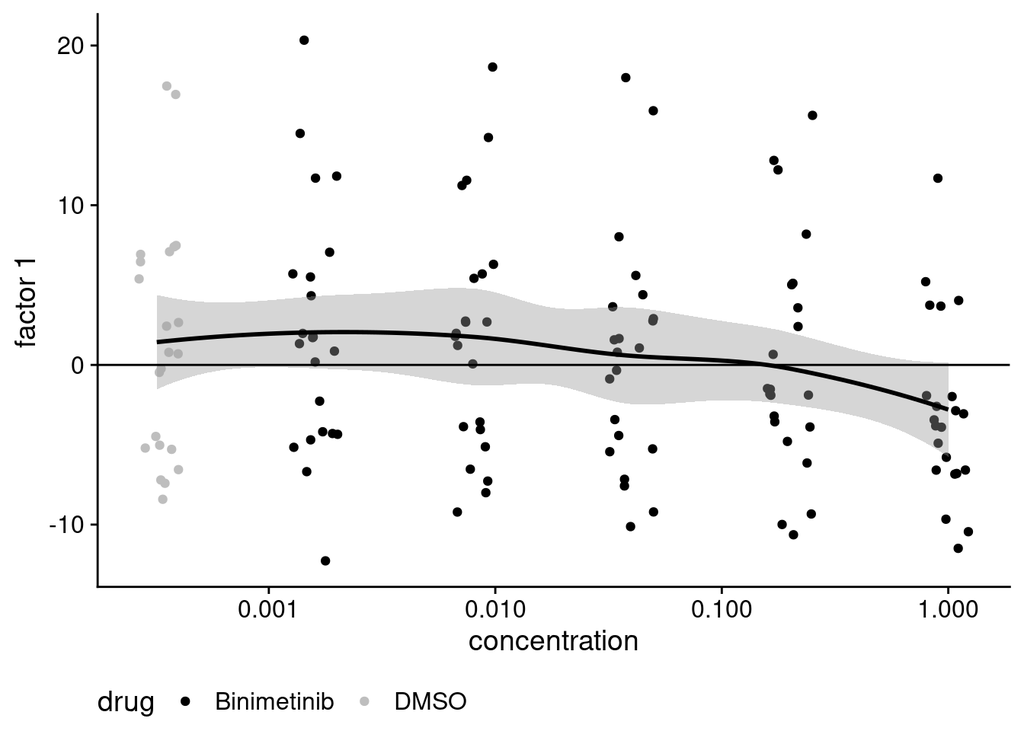

```r
gg_f1_mek_conc <- z_projected_conc_anno_tidy %>%
  filter(drug %in% c("DMSO", "Binimetinib")) %>%
  mutate(concentration = if_else(drug == "DMSO", 0.00032, concentration)) %>% #adding a pseudo conc for plotting
  ggplot(aes(concentration, V1)) +
  geom_jitter(width = 0.1, aes(color = drug)) +
  scale_x_log10() +
  geom_smooth(color = "black") +
  geom_hline(yintercept = 0) +
  theme_cowplot() +
  labs(y = "factor 1") +
  scale_color_manual(values = c("black", "grey")) +
  theme(legend.position = "bottom")

gg_f1_mek_conc + ggsave(here::here("reports/figures/mofa/f1_mek_shift.pdf"), width = 4, height = 4)
```

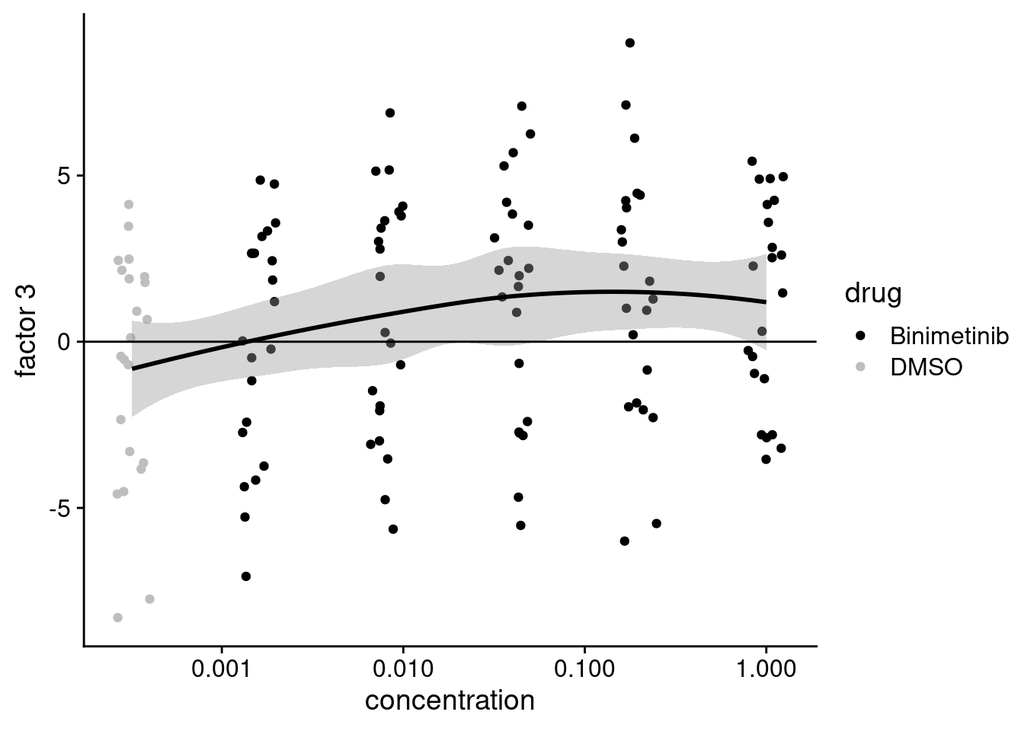

```r
gg_f3_mek_conc <- z_projected_conc_anno_tidy %>%
  filter(drug %in% c("DMSO", "Binimetinib")) %>%
  mutate(concentration = if_else(drug == "DMSO", 0.00032, concentration)) %>% #adding a pseudo conc for plotting
  ggplot(aes(concentration, V3)) +
  geom_jitter(width = 0.1, aes(color = drug)) +
  scale_x_log10() +
  geom_smooth(color = "black") +
  geom_hline(yintercept = 0) +
  theme_cowplot() +
  labs(y = "factor 3") +
  scale_color_manual(values = c("black", "grey"))

gg_f3_mek_conc + ggsave(here::here("reports/figures/mofa/f3_mek_shift.pdf"), width = 4, height = 4)
```

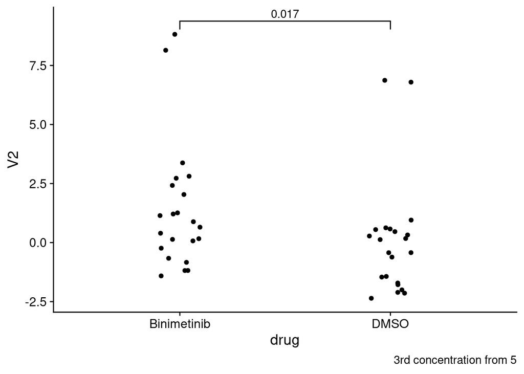

```r
doi <- c("DMSO", "Binimetinib")

gg_f2_shift_signif<- z_projected_conc_anno_tidy %>%
  filter(drug %in% doi) %>%
  filter(concentration == 0.04 | drug == "DMSO") %>%
  ggplot(aes(drug, V2, label = id)) +
  geom_jitter(width = 0.1) +
  ggsignif::geom_signif(comparisons = list(doi)) +
  theme_cowplot() +
  labs(caption = "3rd concentration from 5")

gg_f2_shift_signif + ggsave(here::here("reports/figures/mofa/f2_mek_shift_test.pdf"), width = 4, height = 4)
```

Organoid size does not change as a function of MEKi treatment

```r
umap_df %>%
  filter(drug %in% c("DMSO", "Binimetinib")) %>%
  mutate(concentration = ifelse(drug == "DMSO", 0.00032, concentration)) %>% #adding a pseudo conc for plotting
  mutate(concentration = as.numeric(concentration)) %>%
  ggplot(aes(concentration, v2)) +
  geom_jitter(width = 0.1, aes(color = drug)) +
  scale_x_log10() +
  geom_smooth(color = "black") +
  geom_hline(yintercept = 0) +
  theme_cowplot() +
  labs(y = "factor 2") +
  scale_color_manual(values = c("black", "grey"))
```

```r
umap_df %>%
  filter(drug == "Binimetinib") %>%
  filter(prob_live == 1) %>%
  mutate(concentration = as.numeric(concentration)) %>%
  ggplot(aes(concentration, size_log)) +
  geom_jitter(width = 0.1) +
  stat_summary(fun.y=mean, colour="blue", geom="line", size = 1) + # draw a mean line in the data
  scale_x_log10() +
  labs(title = "Binimetinib, filtering for alive organoids") +
  #facet_grid(prediction ~ line) +
  theme_cowplot()
```

### mTOR inhibitors

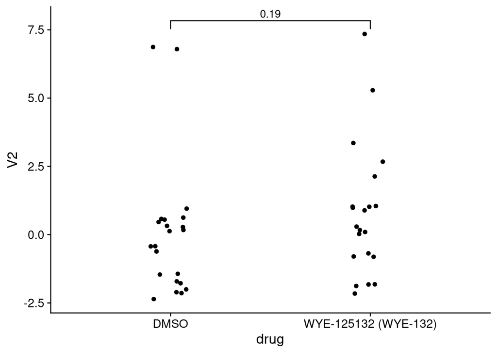

```r
doi <- c("DMSO", "WYE-125132 (WYE-132)")

gg_f1_shift_signif<- z_projected_conc_anno_tidy %>%
  filter(drug %in% doi) %>%
  ggplot(aes(drug, V2, label = id)) +
  geom_jitter(width = 0.1) +
  ggsignif::geom_signif(comparisons = list(doi)) +
  theme_cowplot()

gg_f1_shift_signif + ggsave(here::here("reports/figures/mofa/f1_mtor_shift_test.pdf"), width = 4, height = 4)
```

# morhphology: drug

```r
drug_projection_test_result_drug <- rbind(
  lm(V1 ~ drug + line, data = z_projected_anno_test) %>% summary() %>% broom::tidy() %>% mutate(factor = "factor1"),
  lm(V2 ~ drug + line, data = z_projected_anno_test) %>% summary() %>% broom::tidy() %>% mutate(factor = "factor2"),
  lm(V3 ~ drug + line, data = z_projected_anno_test) %>% summary() %>% broom::tidy() %>% mutate(factor = "factor3"))

drug_projection_test_result_drug <- drug_projection_test_result_drug %>%
  filter(term != "(Intercept)") %>%
  dplyr::select(term, statistic, factor, p.value)
```

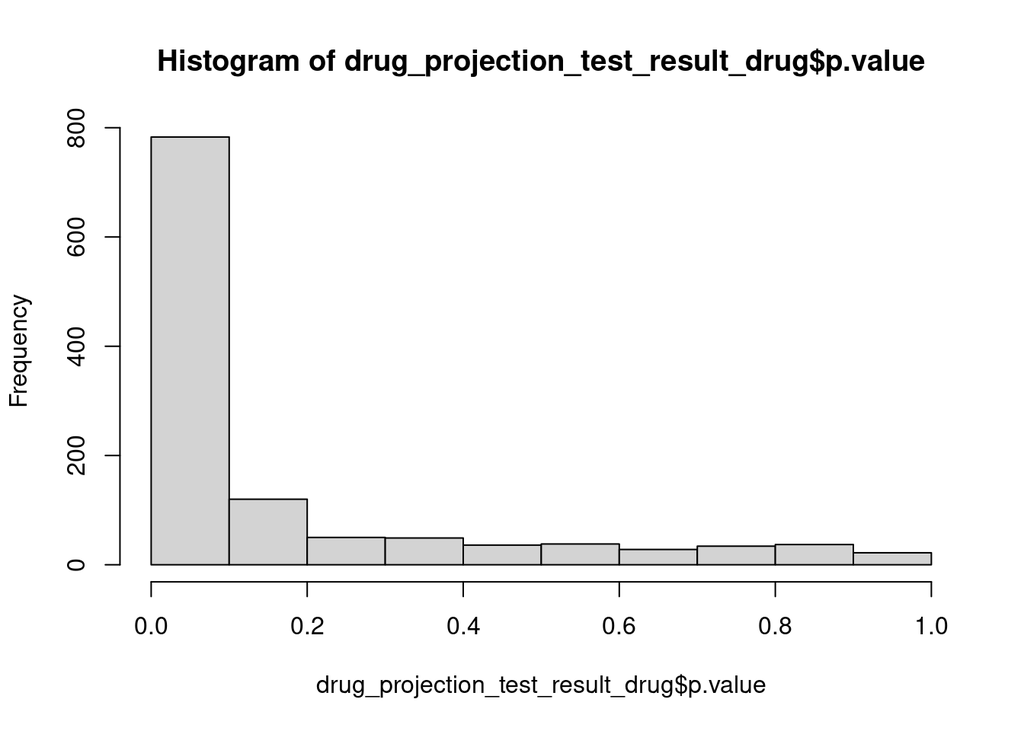

```r
hist(drug_projection_test_result_drug$p.value)
```

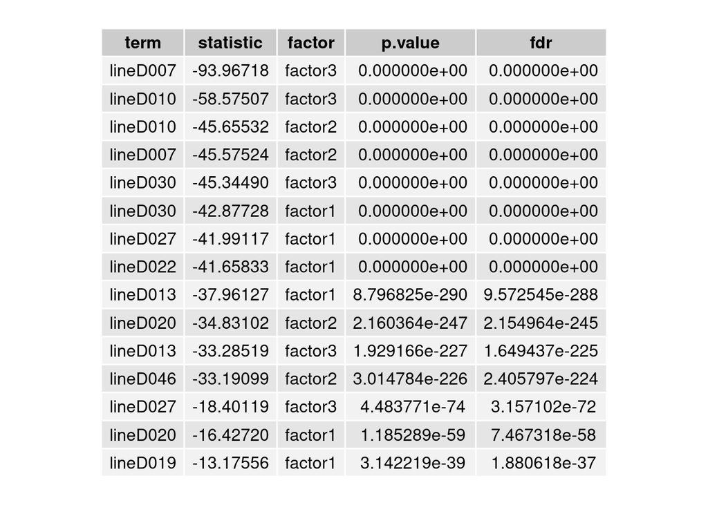

```r
moa_factor_shift <- drug_projection_test_result_drug %>% arrange(statistic) %>%
  mutate(fdr = p.adjust(p.value, method = "BH"))

moa_factor_shift_tbl <- moa_factor_shift%>%
  filter(fdr <= 0.2) %>%
  head(15) %>%
  tableGrob(., theme = ttheme_default(), rows = NULL)

grid.arrange(moa_factor_shift_tbl)
```

```r
moa_factor_shift %>%
  filter(!grepl(term, pattern = "D0")) %>%
  filter(factor == "factor1") %>%
  filter(statistic > 0) %>%
  mutate(drug = substr(term, 5, nchar(.))) %>%
  left_join(drug_anno) %>%
  arrange(desc(statistic))
```

```
## # A tibble: 299 x 7
##    term             statistic factor      p.value       fdr drug          target
##    <chr>                <dbl> <chr>         <dbl>     <dbl> <chr>         <chr>
##  1 drugPP242             5.76 factor1     8.53e-9   3.29e-7 PP242         mTOR
##  2 drugWH-4-023          4.96 factor1     7.15e-7   2.09e-5 WH-4-023      Src
##  3 drugWYE-125132 …      4.90 factor1     9.69e-7   2.70e-5 WYE-125132 (… mTOR
##  4 drugCC-223            4.64 factor1     3.60e-6   8.79e-5 CC-223        mTOR
##  5 drugINK 128 (ML…      4.15 factor1     3.31e-5   6.09e-4 INK 128 (MLN… mTOR
##  6 drugOSI-027           4.12 factor1     3.86e-5   6.89e-4 OSI-027       mTOR
##  7 drugSunitinib M…      4.07 factor1     4.69e-5   7.50e-4 Sunitinib Ma… VEGFR
##  8 drugGDC-0349          3.95 factor1     7.95e-5   1.11e-3 GDC-0349      mTOR
##  9 drugPF-04691502       3.92 factor1     8.91e-5   1.20e-3 PF-04691502   mTOR
## 10 drugWYE-354           3.90 factor1     9.59e-5   1.28e-3 WYE-354       mTOR
## # … with 289 more rows
```

when accounting for line differences, mTOR inhibitors (PP242 and WYE-132) are among the strongest inductors of factor 1

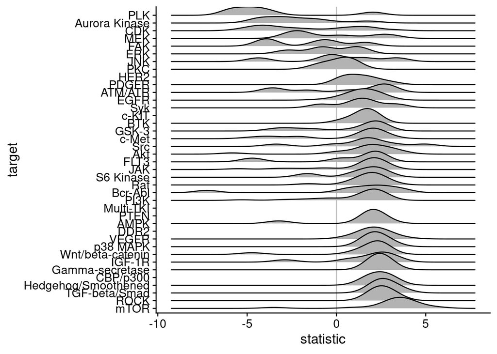

```r
drug_shift_test <- moa_factor_shift %>%
  filter(!grepl(term, pattern = "D0")) %>%
  filter(factor == "factor1") %>%
  mutate(drug = substr(term, 5, nchar(.))) %>%
  left_join(drug_anno)

aggregate_drugs <- drug_shift_test %>% group_by(target) %>% summarise_at(vars(contains("statistic")), funs("median"))

include_drugs <- aggregate_drugs %>% arrange(desc(statistic)) %>% .$target

gg_f1_drug_shift <- drug_shift_test %>%
  drop_na() %>%
  mutate(target = factor(target, levels = include_drugs)) %>%
  ggplot(aes(y = target, x = statistic)) +
  #geom_point() +
  geom_vline(xintercept = 0, color = "grey") +
  ggridges::geom_density_ridges() +

  #coord_flip() +
  cowplot::theme_cowplot()

gg_f1_drug_shift + ggsave(here::here("reports/figures/mofa/f1_ridge_drug_shift.pdf"), width = 4, height = 3)
```

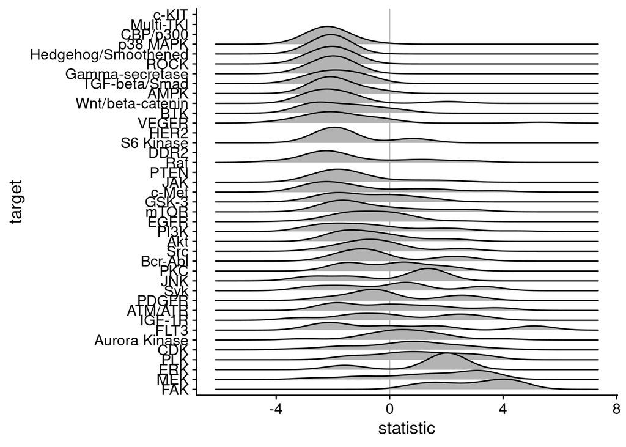

```r
drug_shift_test <- moa_factor_shift %>%
  filter(!grepl(term, pattern = "D0")) %>%
  filter(factor == "factor2") %>%
  mutate(drug = substr(term, 5, nchar(.))) %>%
  left_join(drug_anno)

aggregate_drugs <- drug_shift_test %>% group_by(target) %>% summarise_at(vars(contains("statistic")), funs("mean"))

include_drugs <- aggregate_drugs %>% arrange(desc(statistic)) %>% .$target

gg_f2_drug_shift <- drug_shift_test %>%
  drop_na() %>%
  mutate(target = factor(target, levels = include_drugs)) %>%
  ggplot(aes(y = target, x = statistic)) +
  #geom_point() +
  geom_vline(xintercept = 0, color = "grey") +
  ggridges::geom_density_ridges() +

  #coord_flip() +
  cowplot::theme_cowplot()

gg_f2_drug_shift + ggsave(here::here("reports/figures/mofa/f2_ridge_drug_shift.pdf"), width = 4, height = 3)
```

```r
drug_shift_test %>% arrange(desc(statistic)) %>% filter(factor == "factor2")
```

```
## # A tibble: 393 x 7
##    term             statistic factor    p.value      fdr drug           target
##    <chr>                <dbl> <chr>       <dbl>    <dbl> <chr>          <chr>
##  1 drugSGI-7079          5.30 factor2   1.19e-7  3.81e-6 SGI-7079       VEGFR
##  2 drugKW-2449           5.10 factor2   3.52e-7  1.05e-5 KW-2449        FLT3
##  3 drugBGT226 (NVP…      4.48 factor2   7.53e-6  1.70e-4 BGT226 (NVP-B… PI3K
##  4 drugPF-562271         4.38 factor2   1.21e-5  2.55e-4 PF-562271      FAK
##  5 drugPF-431396         4.14 factor2   3.55e-5  6.43e-4 PF-431396      FAK
##  6 drugJNJ-7706621       4.00 factor2   6.36e-5  9.51e-4 JNJ-7706621    CDK
##  7 drugHesperadin        3.94 factor2   8.32e-5  1.13e-3 Hesperadin     Aurora …
##  8 drugAZ20              3.77 factor2   1.66e-4  2.03e-3 AZ20           ATM/ATR
##  9 drugGolvatinib …      3.71 factor2   2.13e-4  2.45e-3 Golvatinib (E… c-Met
## 10 drugMEK162 (ARR…      3.49 factor2   4.78e-4  4.62e-3 MEK162 (ARRY-… MEK
## # … with 383 more rows
```

```r
z_projected_anno_test
```

[output not shown]

[output cut: 24864 more lines]

## factor shift MOA by line

```r
z_projected_anno_test_line <- z_projected_anno_test %>% mutate(line = substr(line, 1, 4))

drug_projection_test_result_line <- rbind(
  lm(V1 ~ target + line, data = z_projected_anno_test_line) %>% summary() %>% broom::tidy() %>% mutate(factor = "factor1"),
  lm(V2 ~ target + line, data = z_projected_anno_test_line) %>% summary() %>% broom::tidy() %>% mutate(factor = "factor2"),
  lm(V3 ~ target + line, data = z_projected_anno_test_line) %>% summary() %>% broom::tidy() %>% mutate(factor = "factor3"))

drug_projection_test_result_line <- drug_projection_test_result_line %>%
  filter(term != "(Intercept)") %>%
  dplyr::select(term, statistic, factor, p.value)
```

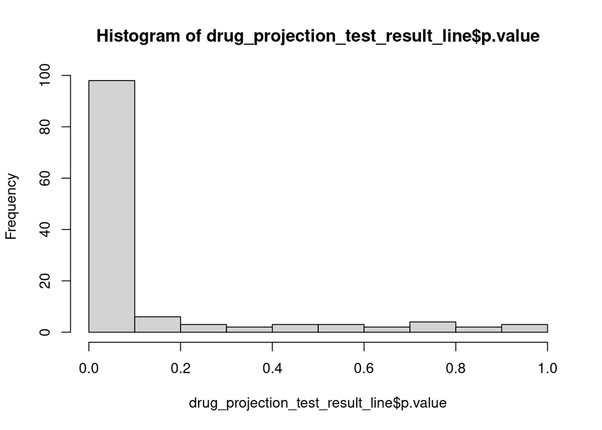

```r
hist(drug_projection_test_result_line$p.value)
```

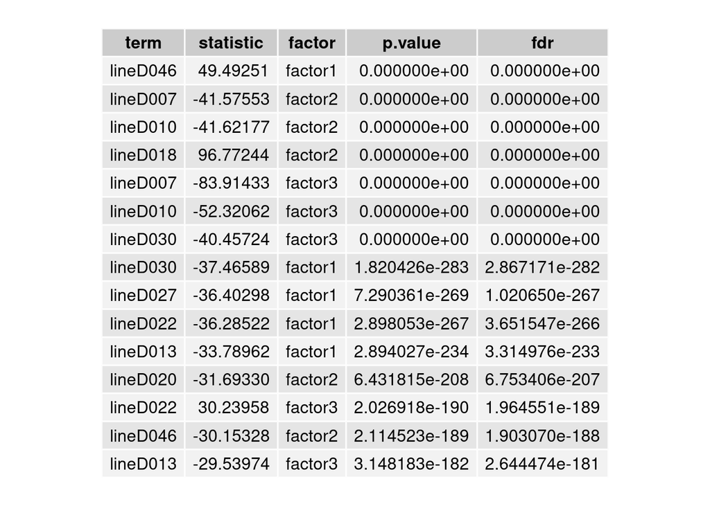

```r
moa_factor_shift_line <- drug_projection_test_result_line %>% arrange(p.value) %>%
  mutate(fdr = p.adjust(p.value, method = "BH"))


moa_factor_shift_tbl <- moa_factor_shift_line%>%
  filter(fdr <= 0.2) %>%
  head(15) %>%
  tableGrob(., theme = ttheme_default(), rows = NULL)

grid.arrange(moa_factor_shift_tbl)
```

decomposing the results

```r
moa_factor_shift_line_tidy <- moa_factor_shift_line %>%
  separate(term, c("line", "drug"), remove = FALSE, sep = ":") %>%
  mutate(type = case_when(is.na(line) ~ "drug",
                          is.na(drug) ~ "line",
                          TRUE ~ "interaction"))
```

D018T01 is exceptionally strong in factor 2, when treated with MEK inhibitors the line shows a strong response with a shift in factor 1. At a first glance, this is in conflict with the observation that factor 2 high lines are relatively insensitive to MEK inhibtors.

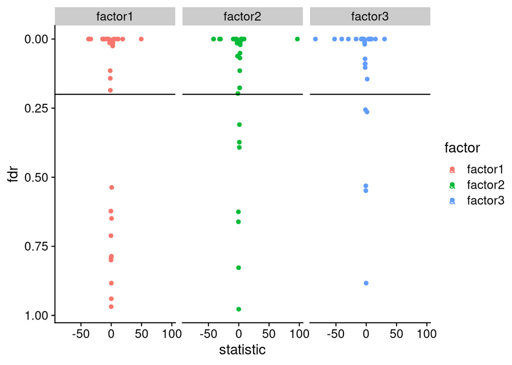

```r
moa_factor_shift_line %>%
  ggplot(aes(statistic, fdr, color = factor, label = term)) +
  geom_point() +
  scale_y_reverse() +
  geom_hline(yintercept = 0.2) +
  theme_cowplot() +
  facet_wrap( ~ factor)+
  ggrepel::geom_text_repel(data = moa_factor_shift %>% filter(term == "targetMEK")) +
  ggrepel::geom_text_repel(data = moa_factor_shift %>% filter(term == "targetAurora Kinase"))
```

```r
  NULL
```